# FE8828 Programming Web Applications in Finance

Week 1 What’s Internet? What’s Web? Launch into the Cloud Catch-up with R

Dr. Yang Ye  
<sub><Email:yy@runchee.com></sub>

Nov 02, 2017

# Introduction to this course

## Topics: Week 1-3

- Week 1:
  1. What’s Internet? What’s Web?
  2. Launch into the Cloud: AWS
  3. R catch-up: R Markdown and Shiny layout
- Week 2:
  1. Data manipulation and visualization: part 1/2
  2. Shiny: part 1/2
- Week 3:
  1. Data manipulation and visualization: part 2/2
  2. Shiny: part 2/2

# Introduction to this course

## Topics: Week 4-6

- Week 4:
  1. Finance application basics
  2. Finance application cases
- Week 5:
  1. Bitcoin and Blockchain
- Week 6:
  1. Further topics of Blockchain
  2. Presentation of Assignment: Web applicaiton.

# Introduction to this course

## Assingments

- Week 1: A static website. A front page, a about page and a description page in the cloud. (due on Week 2)
- Week 2: A dynamic website that can do CRUD. (due on Week 3)
- Week 3: A data-driven website that does data analytics. (due on Week 4)
- Week 4: A finance-data application website. (due on Week 6)
- Week 5: Reading on Blockchain. (due on Week 7) Working on web assignment. (due on Week 6)
- Week 6: Reading of Blockchain. (due on Week 7)

# Introduction to this course

## Objective

1. Know the way of Internet: the network, the cloud and the application.
2. Build real-world data-driven reports and dashboard, data visualization.
3. Latest Internet technology in cryptocurrency and payment system like Bitcoin and Blockchain.

Spectrum. Data -> Model -> Application

[figure not shown]

# Lecture 01: What’s Internet? What’s Web?

## Content

- Network

# Network

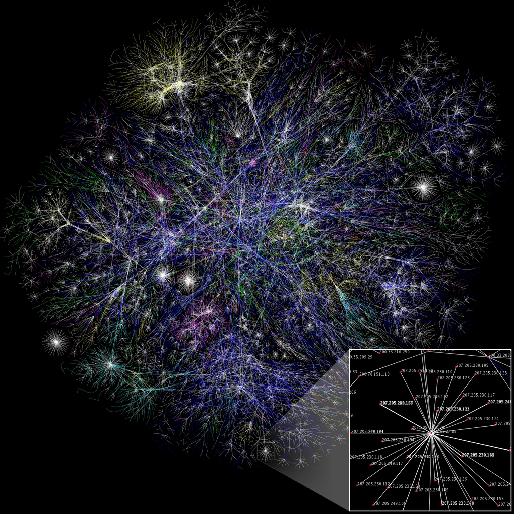

# Introduction

A network is to connet the dots.

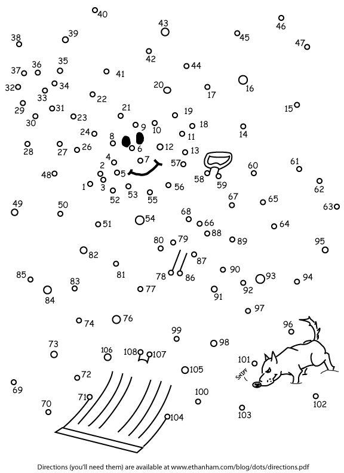

Internet is a super network of the world.

[figure not shown]

# What happens to a computer network?

We need to talk to each other.

Layout: Star v.s. inter-connected.

- In a fully inter-connected network,
1. Information turns to Packet

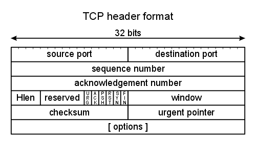

2. Protocol designs the packet TCP/IP Protocol - Internet protocol suite

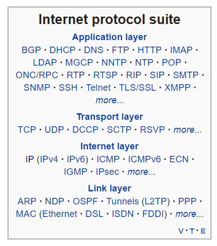

Why the Internet succeeded? What does TCP/IP gives?

The Defense Advanced Research Projects Agency (DARPA), the research branch of the U.S. Department of Defense, created the TCP/IP model in the 1970s for use in ARPANET, a wide area network that preceded the internet.

Four layer approach:

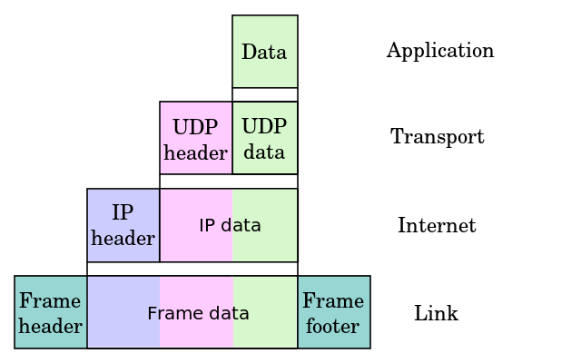

3. Infrastructure is to route the packets to the destination.

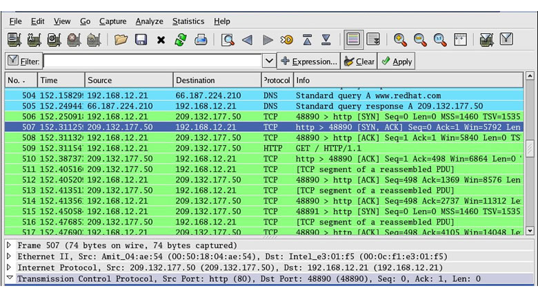

Locally efficient but not very smart. Tries to be very smart. leaves space for improvement. Every equipment manufacturer can improve. Scalable.

# Layered structure:

Low level address

What happens after the cable is plugged in?

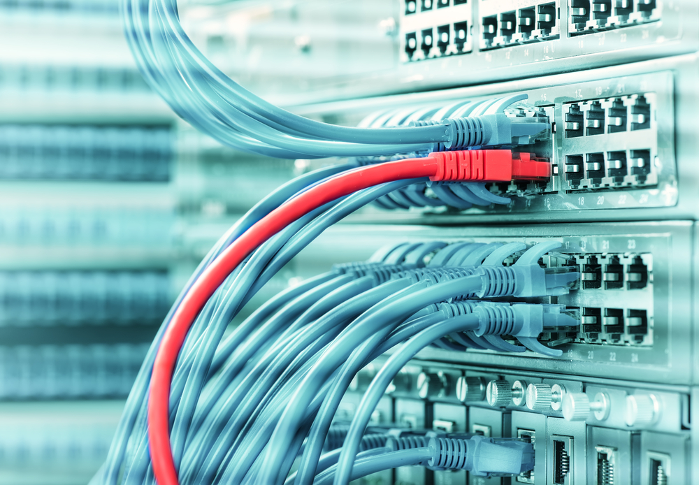

- Every network device has a hardware address
- When a computer connects to the network, the DHCP client, generally a component of the operating system sends out a DHCP request and recieves an offer from a DHCP server. The offer generally contains:

An IP Address A subnet mask for that IP address

A gateway that should be used for off-network requests (like those going via the internet) One or more DNS server addresses so the computer knows where to send DNS requests. Connecting to a Router

When you plug your computer into a router or associate your wireless adapter with an access point, the computer will usually receive a DHCP response directly from the router, which may itself have requested an IP from the ISP for the interface the modem uses. it will then route traffic from the computer via it’s interface connected to the modem where appropriate.